# SQ 011

## Shared Qs (011)

#### Question

1. A landscape architect has 2 spots to plant 2 different trees. The landscape architect has 22 different trees available. How many configurations are possible?

#### Solution

#### Question

2. From a set with 15 elements, how many subsets with 4 elements are possible? (A set is an orderless, nonrepeating collection of elements.)

#### Solution

#### Question

3. A committee is judging the performances of 17 different acrobats. The committee needs to assign 6 equivalent prizes. How many ways could the committee assign the prizes?

#### Solution

#### Question

4. A lottery machine will select a sequence of 2 different numbered marbles. The selection process begins with 23 different numbered marbles to choose from. How many different sequences are possible?

#### Solution

#### Question

5. A designer is choosing a color pallette. There are 22 colors available, but the designer will only choose 3 colors for her pallette. How many pallettes are possible?

#### Solution

#### Question

6. A team has 15 players. The coach needs to pick 3 starters. How many possibilities exist?

#### Solution

#### Question

7. A company needs to select 6 members to be on a committee. The company is considering a pool of 11 applicants. How many possibilities exist?

#### Solution

#### Question

8. A company needs to select 5 members to be on a committee. The company is considering a pool of 11 applicants. How many possibilities exist?

#### Solution

#### Question

9. A landscape architect has 2 spots to plant 2 different trees. The landscape architect has 12 different trees available. How many configurations are possible?

#### Solution

#### Question

10. A bike designer is choosing different colors for the fork, rims, handlebars, cranks, and frame. There are 11 colors available. How many color configurations are possible? (The same color can not be used twice.)

#### Solution

#### Question

11. A spinner was constructed:

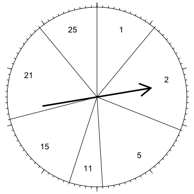

    The spinner’s probability distribution is shown below.

    | $x$ | $P[x]$ |
    | --- | --- |
    | 1 | 0.11 |
    | 2 | 0.20 |
    | 5 | 0.18 |
    | 11 | 0.06 |
    | 15 | 0.16 |
    | 21 | 0.18 |
    | 25 | 0.11 |

    - What is the probability of spinning 5? In other words, what is $P[X=5]$?
    - What is the probability of spinning 15 or 25? In other words, what is $P[X=15 ~\text{ or }~ X=25]$?
    - If spinning twice, what is the probability of first spinning 15 and then spinning 25? In other words, what is $P[X_1=15 ~\text{ and }~ X_2=25]$?
    - What is the probability of spinning at most 2? In other words, what is $P[X\le 2]$?
    - Determine the mean of the probability distribution by using $\mu = \sum x\cdot P[x]$.
    - Determine the standard deviation of the probability distribution by using $\sigma = \sqrt{\sum (x-\mu)^2 \cdot P[x]}$.

#### Solution

#### Question

12. A spinner was constructed:

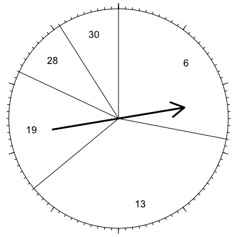

    The spinner’s probability distribution is shown below.

    | $x$ | $P[x]$ |
    | --- | --- |
    | 6 | 0.28 |
    | 13 | 0.36 |
    | 19 | 0.18 |
    | 28 | 0.09 |
    | 30 | 0.09 |

    - What is the probability of spinning 30? In other words, what is $P[X=30]$?
    - What is the probability of spinning 6 or 28? In other words, what is $P[X=6 ~\text{ or }~ X=28]$?
    - If spinning twice, what is the probability of first spinning 6 and then spinning 28? In other words, what is $P[X_1=6 ~\text{ and }~ X_2=28]$?
    - What is the probability of spinning at least 28? In other words, what is $P[X\ge 28]$?
    - Determine the mean of the probability distribution by using $\mu = \sum x\cdot P[x]$.
    - Determine the standard deviation of the probability distribution by using $\sigma = \sqrt{\sum (x-\mu)^2 \cdot P[x]}$.

#### Solution

#### Question

13. A spinner was constructed:

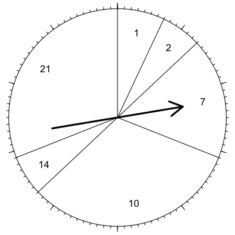

    The spinner’s probability distribution is shown below.

    | $x$ | $P[x]$ |
    | --- | --- |
    | 1 | 0.07 |
    | 2 | 0.06 |
    | 7 | 0.18 |
    | 10 | 0.32 |
    | 14 | 0.06 |
    | 21 | 0.31 |

    - What is the probability of spinning 1? In other words, what is $P[X=1]$?
    - What is the probability of spinning 1 or 7? In other words, what is $P[X=1 ~\text{ or }~ X=7]$?
    - If spinning twice, what is the probability of first spinning 1 and then spinning 7? In other words, what is $P[X_1=1 ~\text{ and }~ X_2=7]$?
    - What is the probability of spinning at most 14? In other words, what is $P[X\le 14]$?
    - Determine the mean of the probability distribution by using $\mu = \sum x\cdot P[x]$.
    - Determine the standard deviation of the probability distribution by using $\sigma = \sqrt{\sum (x-\mu)^2 \cdot P[x]}$.

#### Solution

#### Question

14. A spinner was constructed:

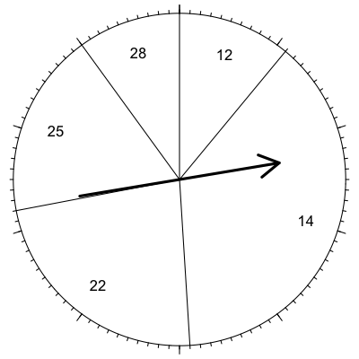

    The spinner’s probability distribution is shown below.

    | $x$ | $P[x]$ |
    | --- | --- |
    | 12 | 0.11 |
    | 14 | 0.38 |
    | 22 | 0.23 |
    | 25 | 0.18 |
    | 28 | 0.10 |

    - What is the probability of spinning 22? In other words, what is $P[X=22]$?
    - What is the probability of spinning 22 or 28? In other words, what is $P[X=22 ~\text{ or }~ X=28]$?
    - If spinning twice, what is the probability of first spinning 22 and then spinning 28? In other words, what is $P[X_1=22 ~\text{ and }~ X_2=28]$?
    - What is the probability of spinning at most 22? In other words, what is $P[X\le 22]$?
    - Determine the mean of the probability distribution by using $\mu = \sum x\cdot P[x]$.
    - Determine the standard deviation of the probability distribution by using $\sigma = \sqrt{\sum (x-\mu)^2 \cdot P[x]}$.

#### Solution

#### Question

15. A spinner was constructed:

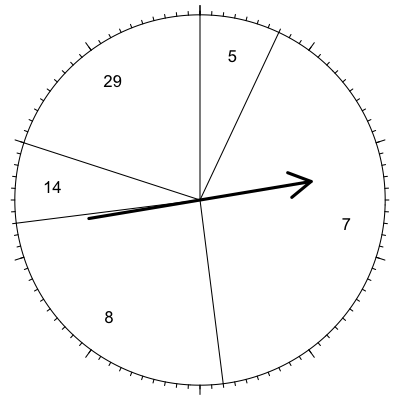

    The spinner’s probability distribution is shown below.

    | $x$ | $P[x]$ |
    | --- | --- |
    | 5 | 0.07 |
    | 7 | 0.41 |
    | 8 | 0.25 |
    | 14 | 0.07 |
    | 29 | 0.20 |

    - What is the probability of spinning 14? In other words, what is $P[X=14]$?
    - What is the probability of spinning 5 or 7? In other words, what is $P[X=5 ~\text{ or }~ X=7]$?
    - If spinning twice, what is the probability of first spinning 5 and then spinning 7? In other words, what is $P[X_1=5 ~\text{ and }~ X_2=7]$?
    - What is the probability of spinning at least 14? In other words, what is $P[X\ge 14]$?
    - Determine the mean of the probability distribution by using $\mu = \sum x\cdot P[x]$.
    - Determine the standard deviation of the probability distribution by using $\sigma = \sqrt{\sum (x-\mu)^2 \cdot P[x]}$.

#### Solution

#### Question

16. A spinner was constructed:

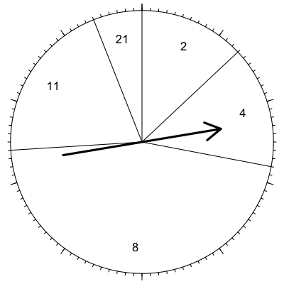

    The spinner’s probability distribution is shown below.

    | $x$ | $P[x]$ |
    | --- | --- |
    | 2 | 0.13 |
    | 4 | 0.15 |
    | 8 | 0.46 |
    | 11 | 0.20 |
    | 21 | 0.06 |

    - What is the probability of spinning 4? In other words, what is $P[X=4]$?
    - What is the probability of spinning 4 or 11? In other words, what is $P[X=4 ~\text{ or }~ X=11]$?
    - If spinning twice, what is the probability of first spinning 4 and then spinning 11? In other words, what is $P[X_1=4 ~\text{ and }~ X_2=11]$?
    - What is the probability of spinning at least 4? In other words, what is $P[X\ge 4]$?
    - Determine the mean of the probability distribution by using $\mu = \sum x\cdot P[x]$.
    - Determine the standard deviation of the probability distribution by using $\sigma = \sqrt{\sum (x-\mu)^2 \cdot P[x]}$.

#### Solution

#### Question

17. A spinner was constructed:

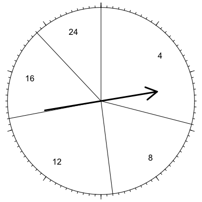

    The spinner’s probability distribution is shown below.

    | $x$ | $P[x]$ |
    | --- | --- |
    | 4 | 0.29 |
    | 8 | 0.19 |
    | 12 | 0.24 |
    | 16 | 0.16 |
    | 24 | 0.12 |

    - What is the probability of spinning 12? In other words, what is $P[X=12]$?
    - What is the probability of spinning 8 or 12? In other words, what is $P[X=8 ~\text{ or }~ X=12]$?
    - If spinning twice, what is the probability of first spinning 8 and then spinning 12? In other words, what is $P[X_1=8 ~\text{ and }~ X_2=12]$?
    - What is the probability of spinning at least 8? In other words, what is $P[X\ge 8]$?
    - Determine the mean of the probability distribution by using $\mu = \sum x\cdot P[x]$.
    - Determine the standard deviation of the probability distribution by using $\sigma = \sqrt{\sum (x-\mu)^2 \cdot P[x]}$.

#### Solution

#### Question

18. A spinner was constructed:

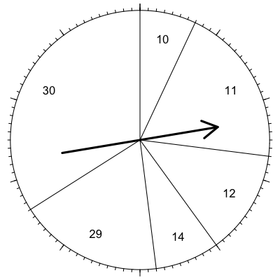

    The spinner’s probability distribution is shown below.

    | $x$ | $P[x]$ |
    | --- | --- |
    | 10 | 0.07 |
    | 11 | 0.20 |
    | 12 | 0.13 |
    | 14 | 0.08 |
    | 29 | 0.18 |
    | 30 | 0.34 |

    - What is the probability of spinning 11? In other words, what is $P[X=11]$?
    - What is the probability of spinning 29 or 30? In other words, what is $P[X=29 ~\text{ or }~ X=30]$?
    - If spinning twice, what is the probability of first spinning 29 and then spinning 30? In other words, what is $P[X_1=29 ~\text{ and }~ X_2=30]$?
    - What is the probability of spinning at least 29? In other words, what is $P[X\ge 29]$?
    - Determine the mean of the probability distribution by using $\mu = \sum x\cdot P[x]$.
    - Determine the standard deviation of the probability distribution by using $\sigma = \sqrt{\sum (x-\mu)^2 \cdot P[x]}$.

#### Solution

#### Question

19. A spinner was constructed:

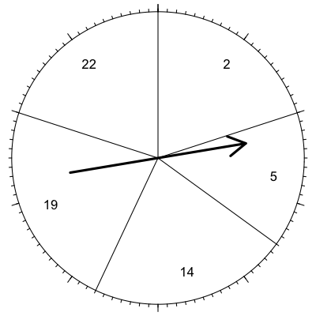

    The spinner’s probability distribution is shown below.

    | $x$ | $P[x]$ |
    | --- | --- |
    | 2 | 0.20 |
    | 5 | 0.15 |
    | 14 | 0.22 |
    | 19 | 0.23 |
    | 22 | 0.20 |

    - What is the probability of spinning 14? In other words, what is $P[X=14]$?
    - What is the probability of spinning 2 or 14? In other words, what is $P[X=2 ~\text{ or }~ X=14]$?
    - If spinning twice, what is the probability of first spinning 2 and then spinning 14? In other words, what is $P[X_1=2 ~\text{ and }~ X_2=14]$?
    - What is the probability of spinning at least 19? In other words, what is $P[X\ge 19]$?
    - Determine the mean of the probability distribution by using $\mu = \sum x\cdot P[x]$.
    - Determine the standard deviation of the probability distribution by using $\sigma = \sqrt{\sum (x-\mu)^2 \cdot P[x]}$.

#### Solution

#### Question

20. A spinner was constructed:

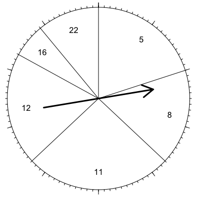

    The spinner’s probability distribution is shown below.

    | $x$ | $P[x]$ |
    | --- | --- |
    | 5 | 0.20 |
    | 8 | 0.17 |
    | 11 | 0.26 |
    | 12 | 0.20 |
    | 16 | 0.06 |
    | 22 | 0.11 |

    - What is the probability of spinning 16? In other words, what is $P[X=16]$?
    - What is the probability of spinning 5 or 8? In other words, what is $P[X=5 ~\text{ or }~ X=8]$?
    - If spinning twice, what is the probability of first spinning 5 and then spinning 8? In other words, what is $P[X_1=5 ~\text{ and }~ X_2=8]$?
    - What is the probability of spinning at most 16? In other words, what is $P[X\le 16]$?
    - Determine the mean of the probability distribution by using $\mu = \sum x\cdot P[x]$.
    - Determine the standard deviation of the probability distribution by using $\sigma = \sqrt{\sum (x-\mu)^2 \cdot P[x]}$.

#### Solution

#### Question

21. In some situation, each trial has 0.36 probability of success. There will be 7 trials. (Thus the number of successes will follow a [binomial distribution](https://en.wikipedia.org/wiki/Binomial_distribution).)

    What is the probability that the number of successes is **less than** $3$.

#### Solution

#### Question

22. In some situation, each trial has 0.69 probability of success. There will be 9 trials. (Thus the number of successes will follow a [binomial distribution](https://en.wikipedia.org/wiki/Binomial_distribution).)

    What is the probability that the number of successes is **at least** $6$.

#### Solution

#### Question

23. In some situation, each trial has 0.6 probability of success. There will be 7 trials. (Thus the number of successes will follow a [binomial distribution](https://en.wikipedia.org/wiki/Binomial_distribution).)

    What is the probability that the number of successes is **more than** $4$.

#### Solution

#### Question

24. In some situation, each trial has 0.58 probability of success. There will be 8 trials. (Thus the number of successes will follow a [binomial distribution](https://en.wikipedia.org/wiki/Binomial_distribution).)

    What is the probability that the number of successes is **at least** $5$.

#### Solution

#### Question

25. In some situation, each trial has 0.33 probability of success. There will be 9 trials. (Thus the number of successes will follow a [binomial distribution](https://en.wikipedia.org/wiki/Binomial_distribution).)

    What is the probability that the number of successes is **less than** $5$.

#### Solution

#### Question

26. In some situation, each trial has 0.53 probability of success. There will be 7 trials. (Thus the number of successes will follow a [binomial distribution](https://en.wikipedia.org/wiki/Binomial_distribution).)

    What is the probability that the number of successes is **exactly** $3$.

#### Solution

#### Question

27. In some situation, each trial has 0.35 probability of success. There will be 7 trials. (Thus the number of successes will follow a [binomial distribution](https://en.wikipedia.org/wiki/Binomial_distribution).)

    What is the probability that the number of successes is **exactly** $3$.

#### Solution

#### Question

28. In some situation, each trial has 0.37 probability of success. There will be 8 trials. (Thus the number of successes will follow a [binomial distribution](https://en.wikipedia.org/wiki/Binomial_distribution).)

    What is the probability that the number of successes is **at most** $5$.

#### Solution

#### Question

29. In some situation, each trial has 0.66 probability of success. There will be 10 trials. (Thus the number of successes will follow a [binomial distribution](https://en.wikipedia.org/wiki/Binomial_distribution).)

    What is the probability that the number of successes is **at least** $7$.

#### Solution

#### Question

30. In some situation, each trial has 0.31 probability of success. There will be 7 trials. (Thus the number of successes will follow a [binomial distribution](https://en.wikipedia.org/wiki/Binomial_distribution).)

    What is the probability that the number of successes is **at most** $4$.

#### Solution